# Project 2 - Internet of Things

Viet Ba Mai, Piotr Kamoda

December, 10th 2016

# Introduction

Given are two datasets:

- dane_obserwacyjne - information about the duration and type of interactions (activities) done by students, potentially with other ones, in relation to exhibitions of Copernicus Center.
- dane_kwestionariuszowe - information about the aforemantioned students covering their aspirations, parents job, school and grades.

The goal of this project is to **explore and analyse given** data. Important aspects to consider include:

- relationship between the duration of an activity and variables like: student’s knowledge, parents occupation etc.
- average distribution time of interaction with a given machine
- other

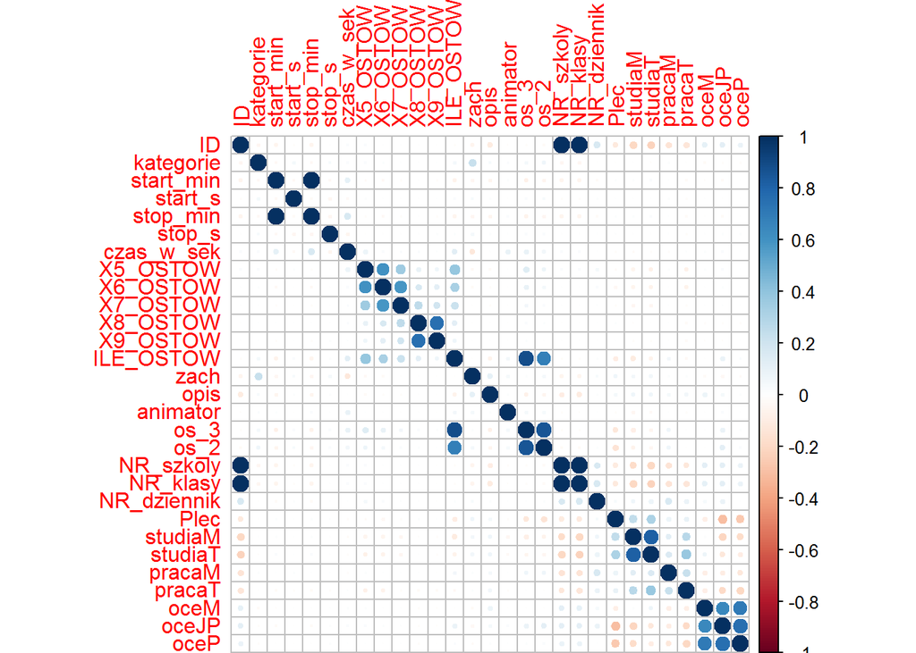

The correlation plot shows that most of attributes are not related. To confirm or deny this we must perform data exploration.

# Exhibit analysis

In this section we will analyse the exhibit data and find relations between several aggregates such as the average duration of interaction.

## Unit/Event Type

Analysed attributes are aggregated by the ekspot variable which describes a display unit or an event.

```
##  ALARM  STATKU OKNO KOPERNIKA           INNE    TORDO OGNIA  KOSMICZNY LEJ
##            222            208            178            112             93
##     MYDLA ŚCIA
##             93
```

```
##    Min. 1st Qu.  Median    Mean 3rd Qu.    Max.
##    0.00   27.88   42.52   70.47   66.12 1014.00
```

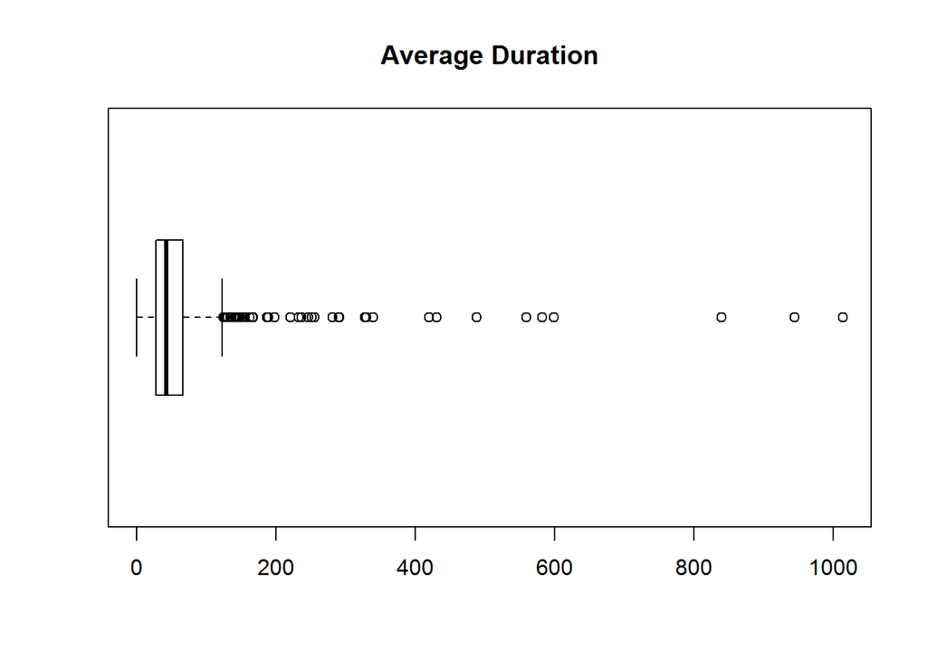

```
##    Min. 1st Qu.  Median    Mean 3rd Qu.    Max.
##     1.0     4.0    18.0    20.3    33.0   100.0
```

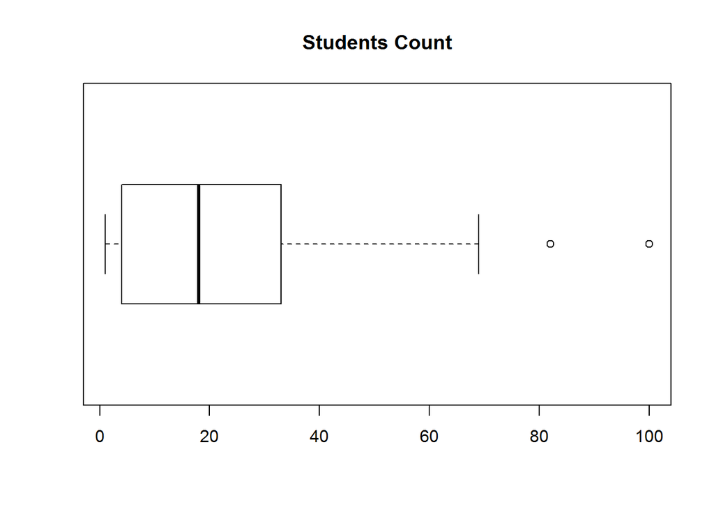

```
##    Min. 1st Qu.  Median    Mean 3rd Qu.    Max.
##  0.0000  1.0000  1.0000  0.9728  1.0000  4.0000
```

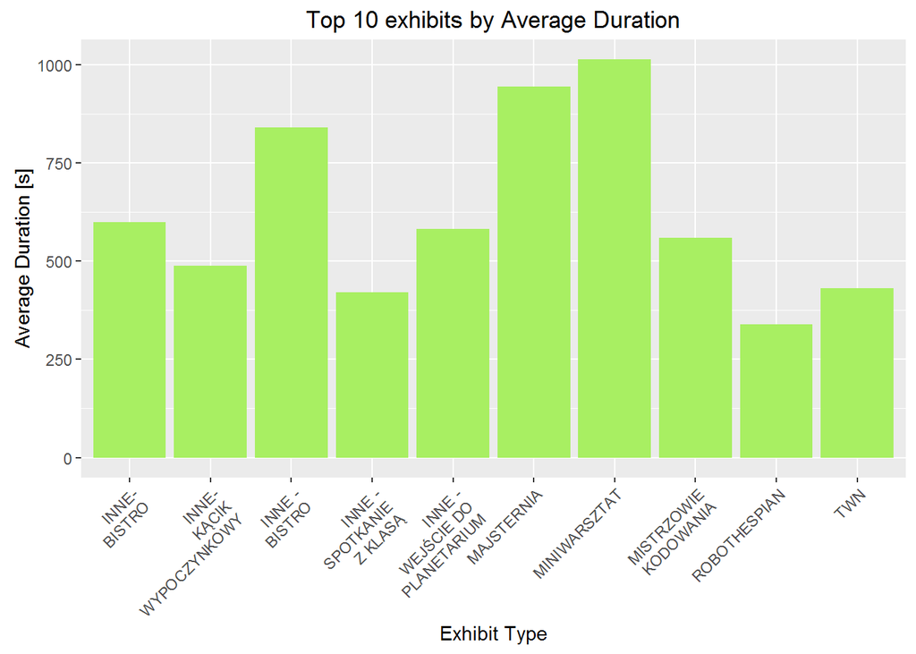

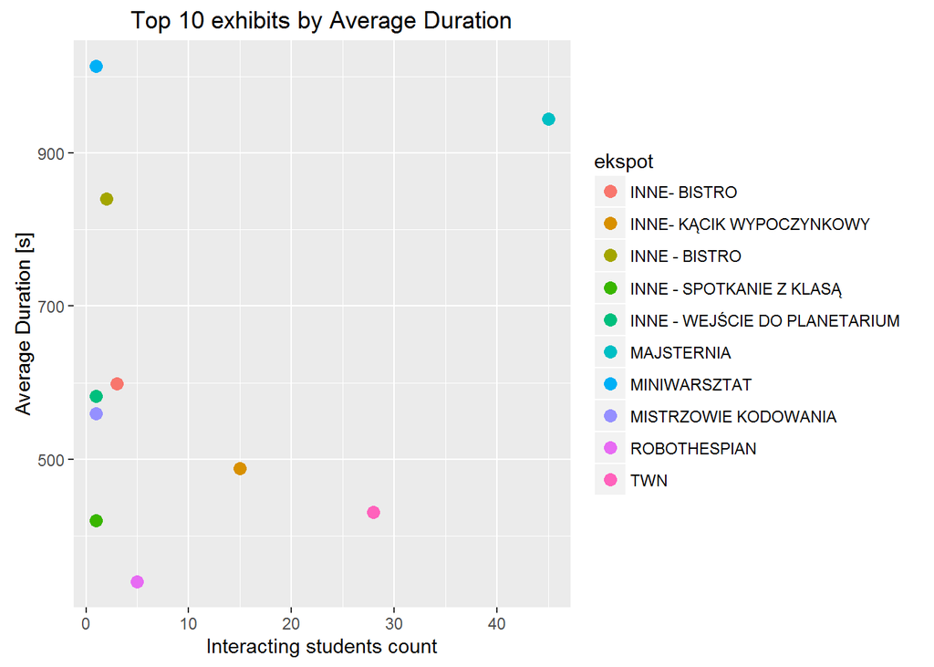

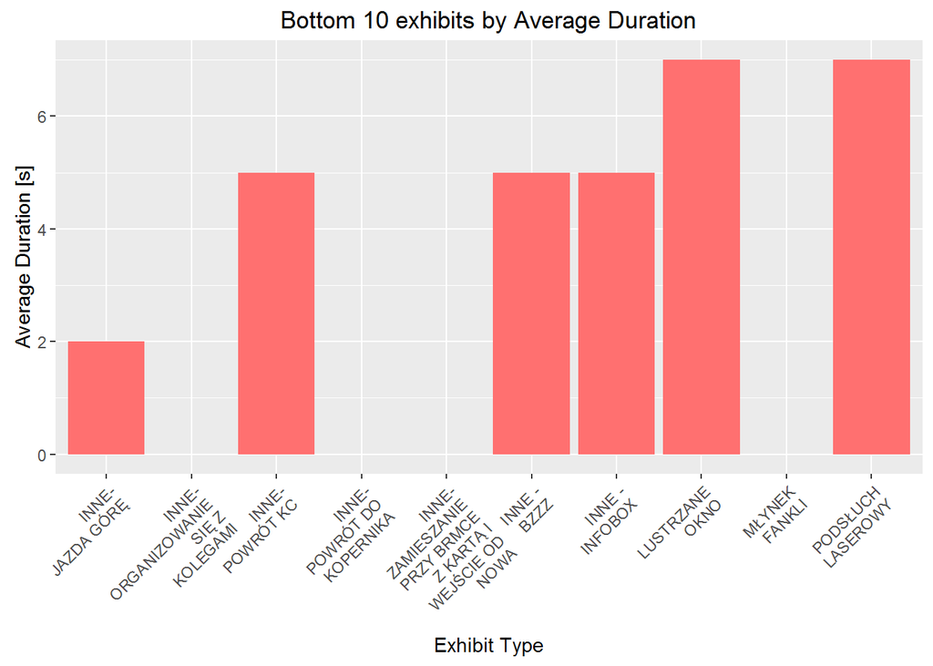

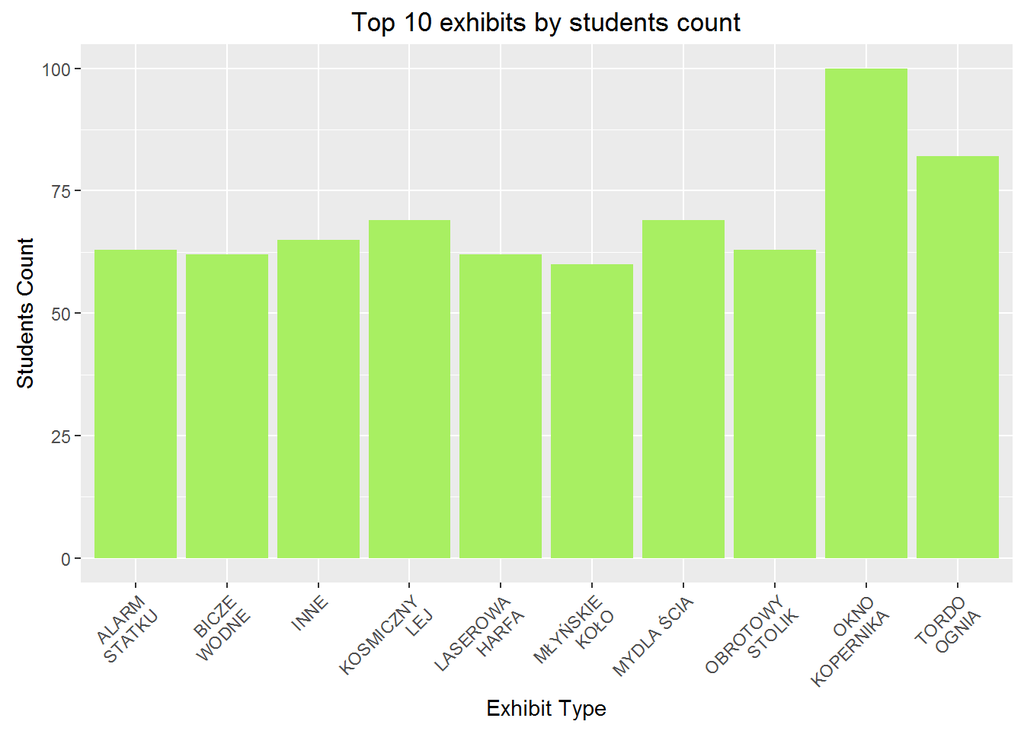

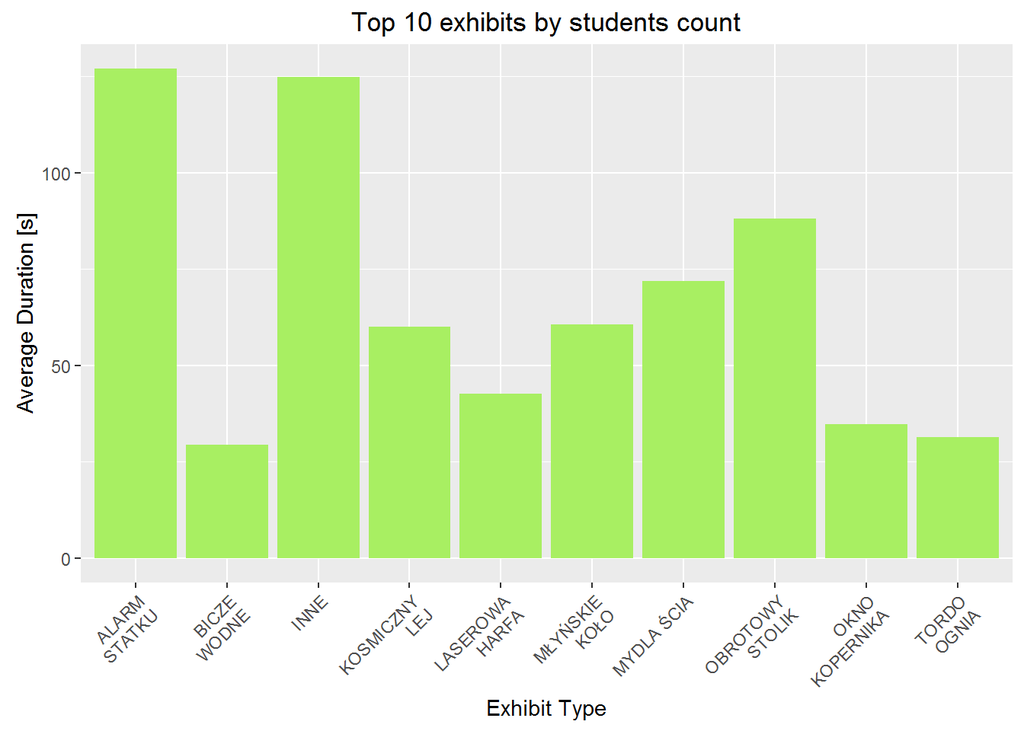

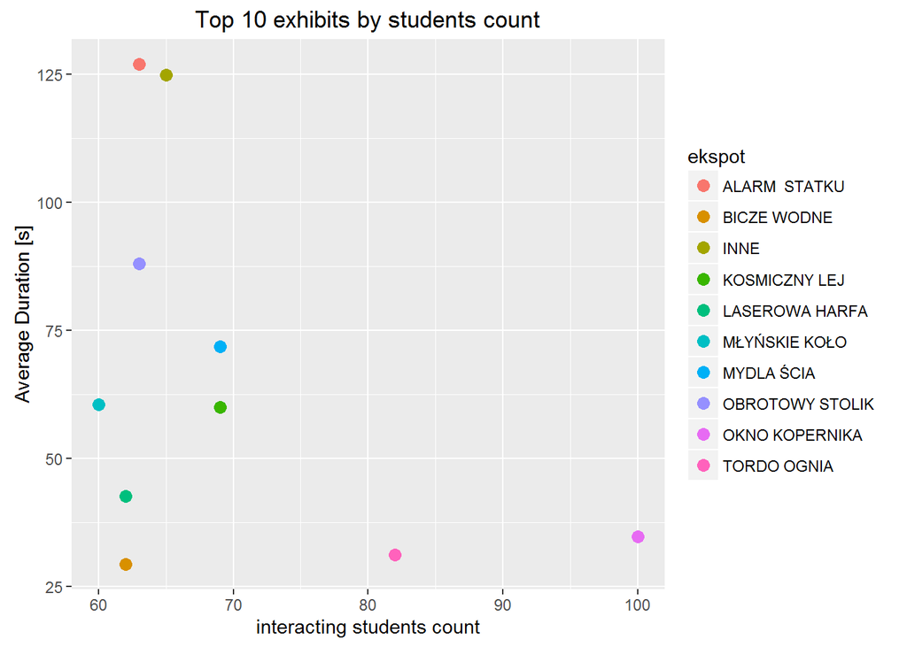

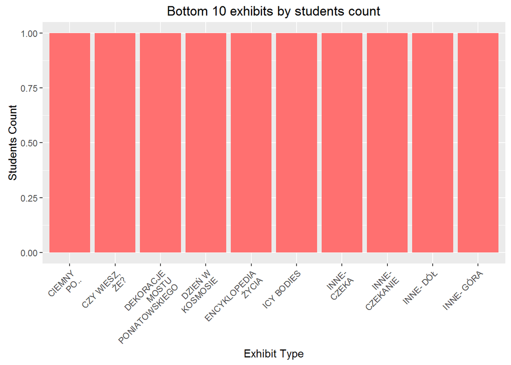

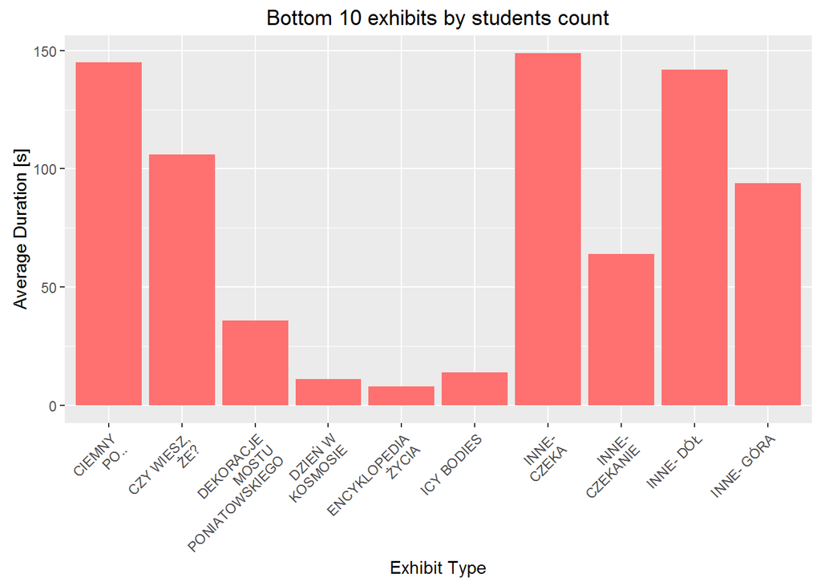

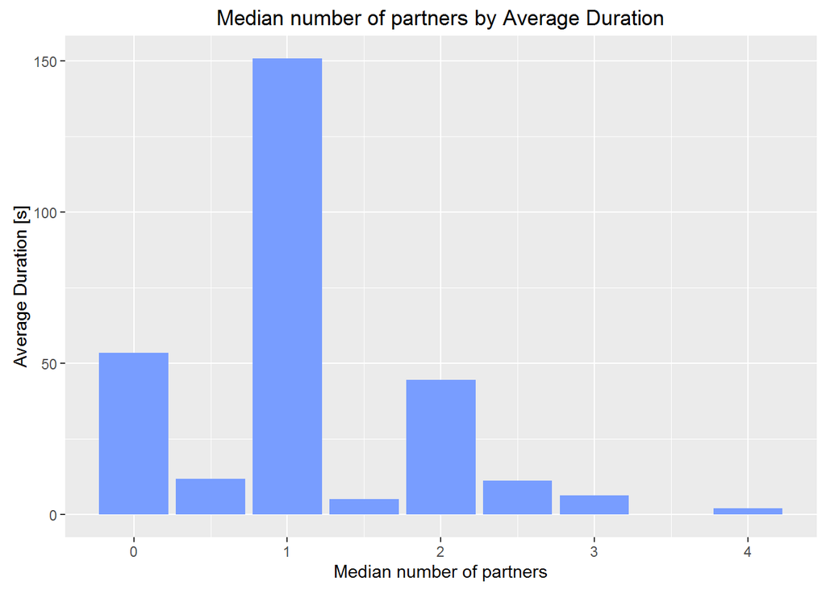

We can see that the units with which the average duration time was the longest are Miniwarsztat and Majsternia with the time being over 15 minutes. This is natural as they are events engaging students into some activities.

Additionally in students visiting in pairs seem to take longest time interacting with units.

## By Category

There are three categories:

- Breaks
- Exhibits
- Other Activities (f.e. theatrical performance)

In this section unit categories as analysed against the average duration, students count and unit count.

```
##    Min. 1st Qu.  Median    Mean 3rd Qu.    Max.    NA's
##   1.000   2.000   2.000   1.973   2.000   3.000      61
```

```
##    Min. 1st Qu.  Median    Mean 3rd Qu.    Max.
##   53.92  125.50  197.00  260.60  363.90  530.80
```

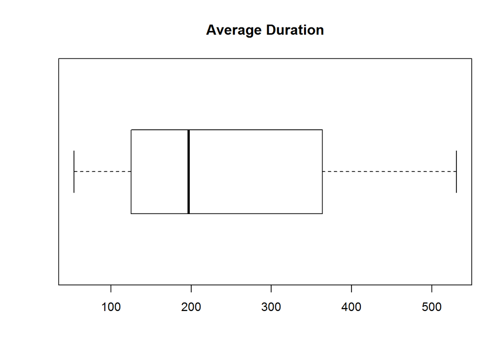

```
##    Min. 1st Qu.  Median    Mean 3rd Qu.    Max.
##    77.0    94.5   112.0   107.0   122.0   132.0
```

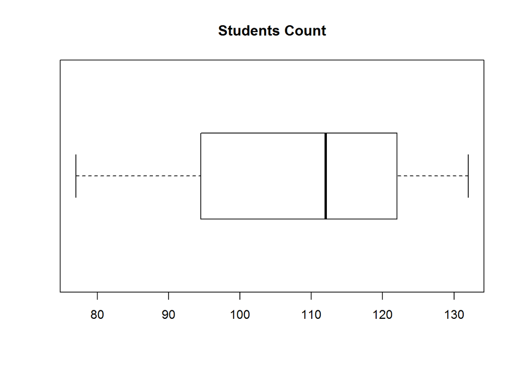

```
##    Min. 1st Qu.  Median    Mean 3rd Qu.    Max.
##       1       1       1       1       1       1
```

```
##    Min. 1st Qu.  Median    Mean 3rd Qu.    Max.
##    77.0    94.5   112.0   107.0   122.0   132.0
```

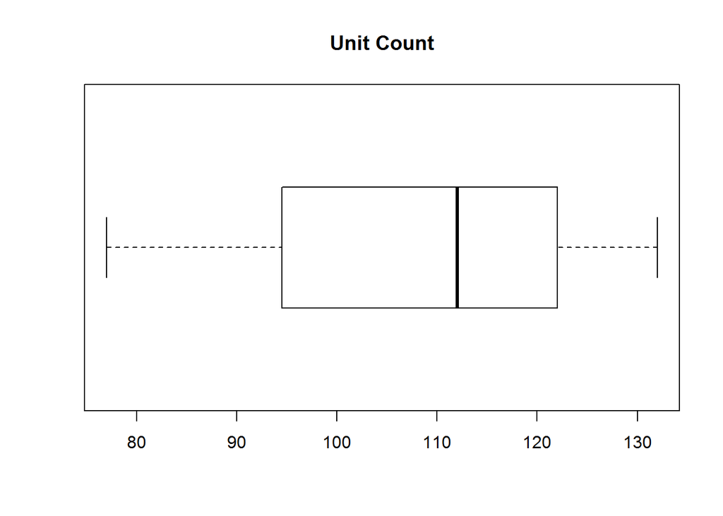

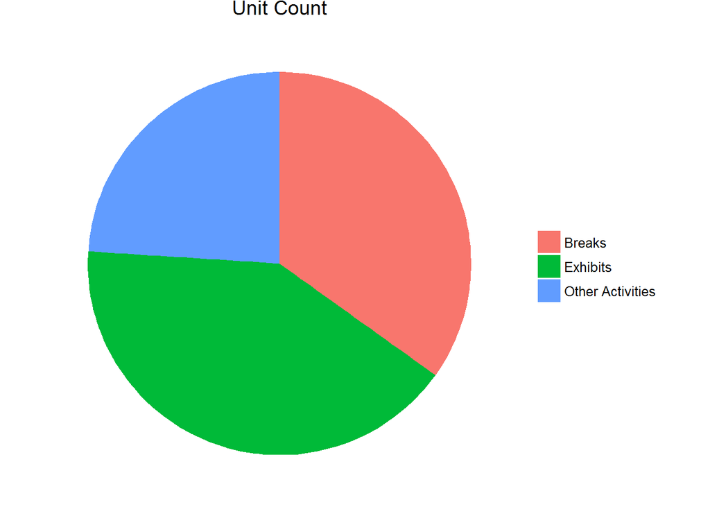

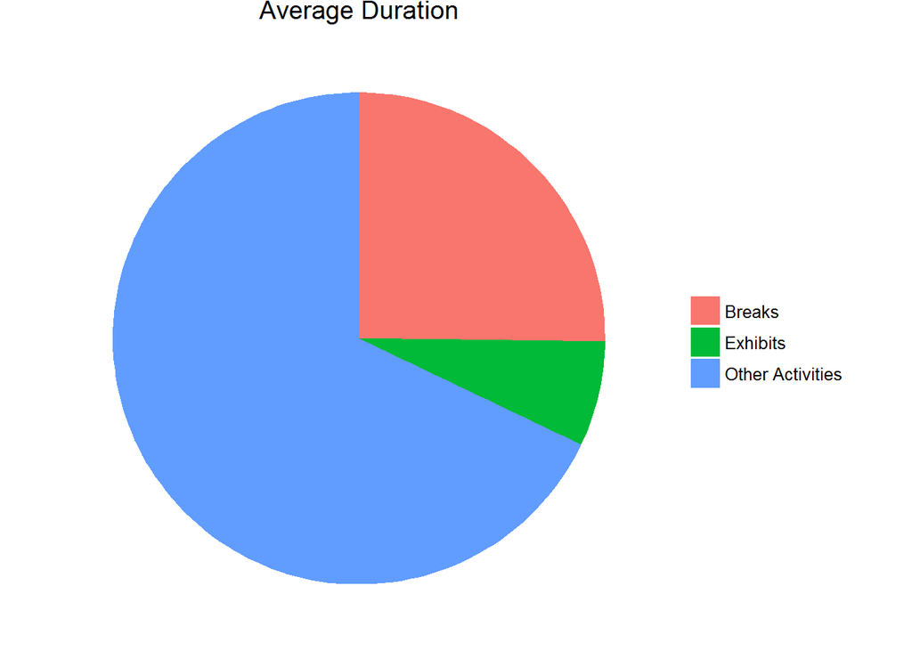

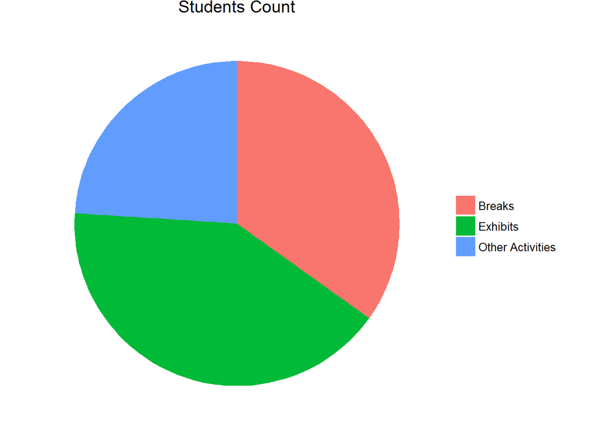

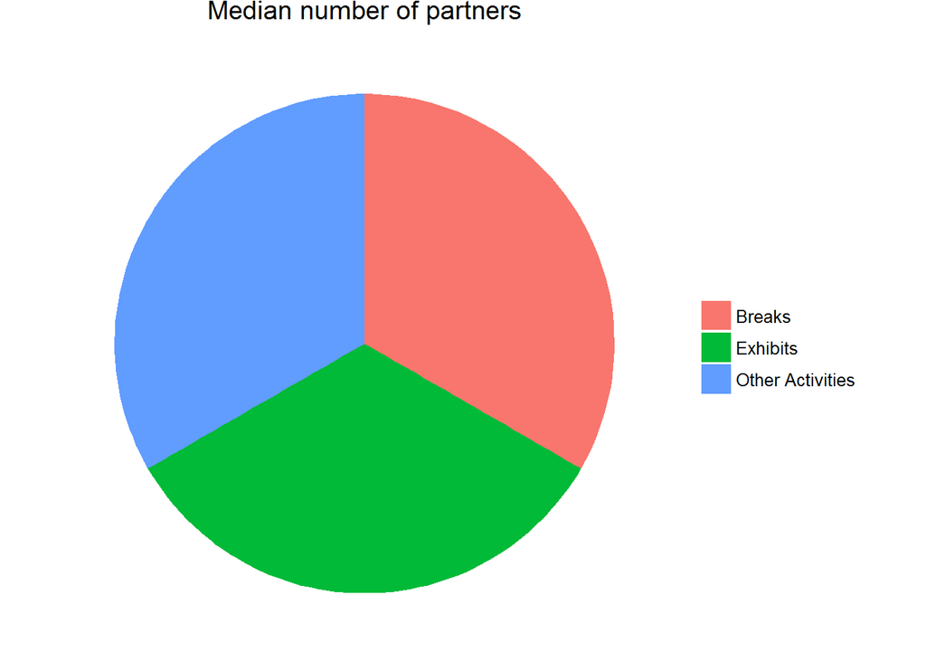

The largest category is Exhibits. Again, it can be observed that other activities which include events are the longest. This is not surprising as most of them have by default some time duration.

The shortest time is spent on Exhibits, however they are also the most popular category among the students. This implies that pupils pay more interest in short interaction categories.

There is almost no difference in the number of accompanied students for each category.

## By Interactions

There are different types of student interactions with units. They include:

- Experimenting
- Looking
- Touching
- Using

Interactions will be analysed in terms of duration, students count and unit count.

```
##    Min. 1st Qu.  Median    Mean 3rd Qu.    Max.    NA's
##   1.000   2.000   3.000   2.432   3.000   4.000     887
```

```
##    Min. 1st Qu.  Median    Mean 3rd Qu.    Max.
##   34.12   36.16   49.16   58.96   71.96  103.40
```

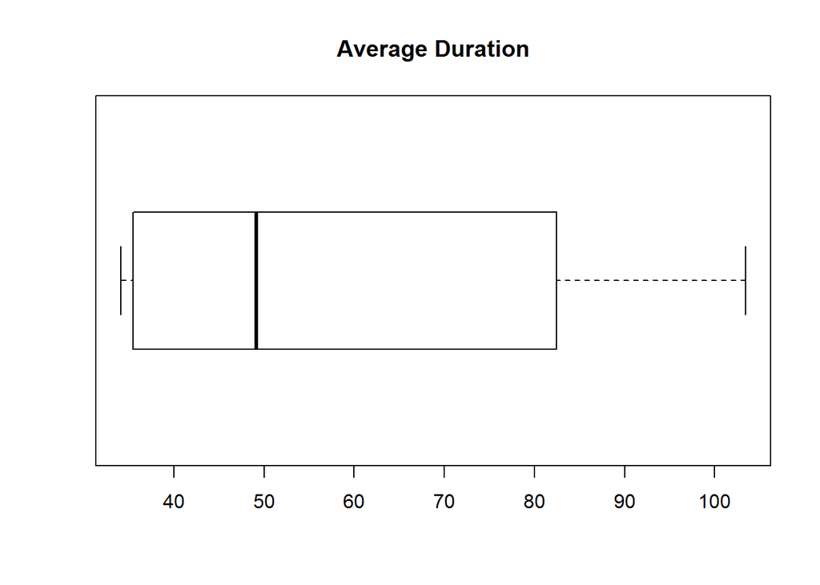

```
##    Min. 1st Qu.  Median    Mean 3rd Qu.    Max.
##   110.0   125.0   130.5   125.8   131.2   132.0
```

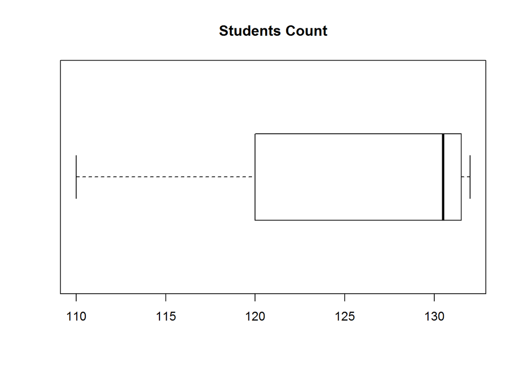

```
## Length  Class   Mode
##      0   NULL   NULL
```

```
##    Min. 1st Qu.  Median    Mean 3rd Qu.    Max.
##   110.0   125.0   130.5   125.8   131.2   132.0
```

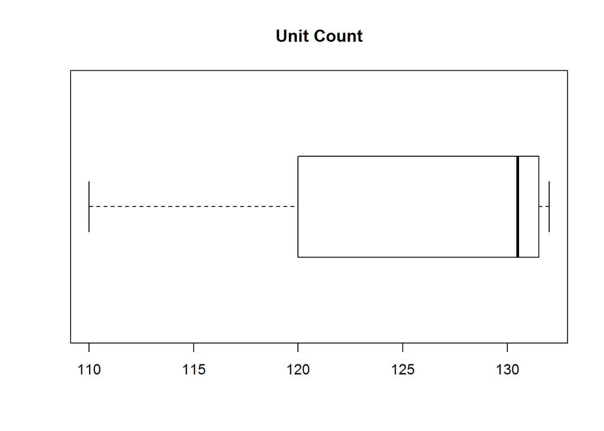

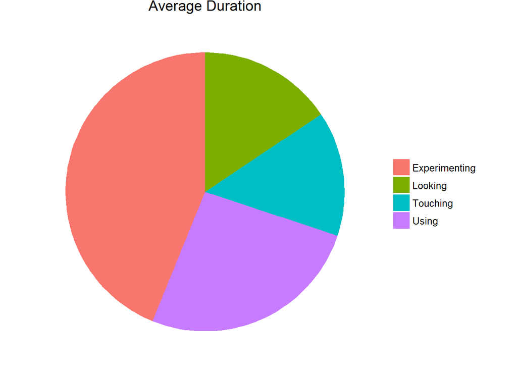

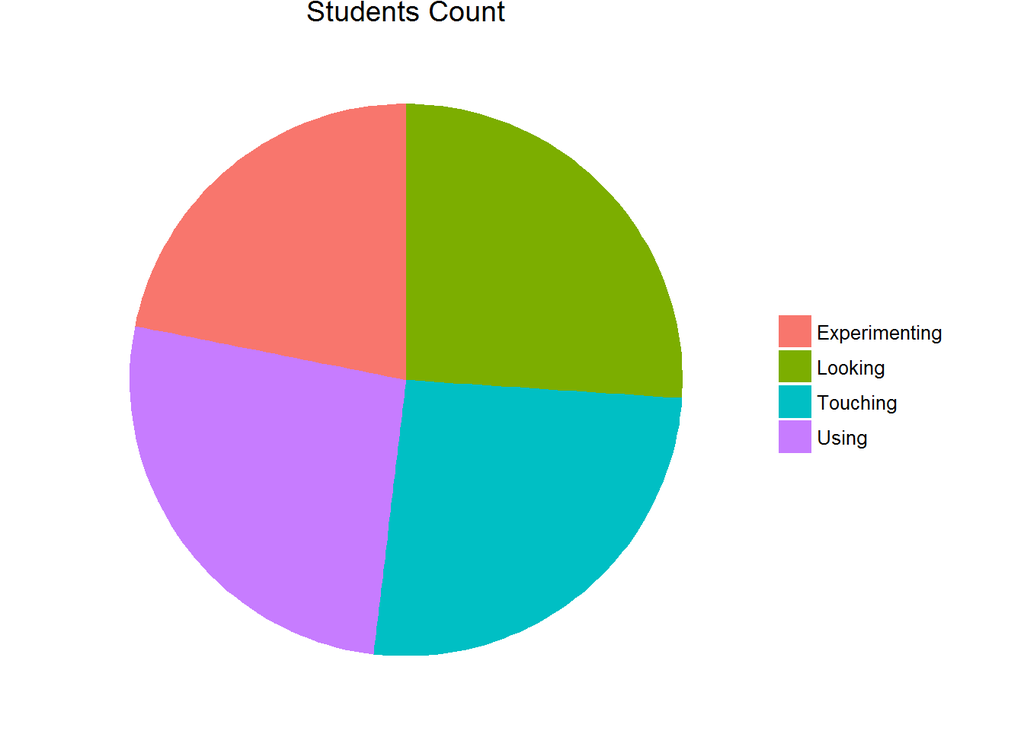

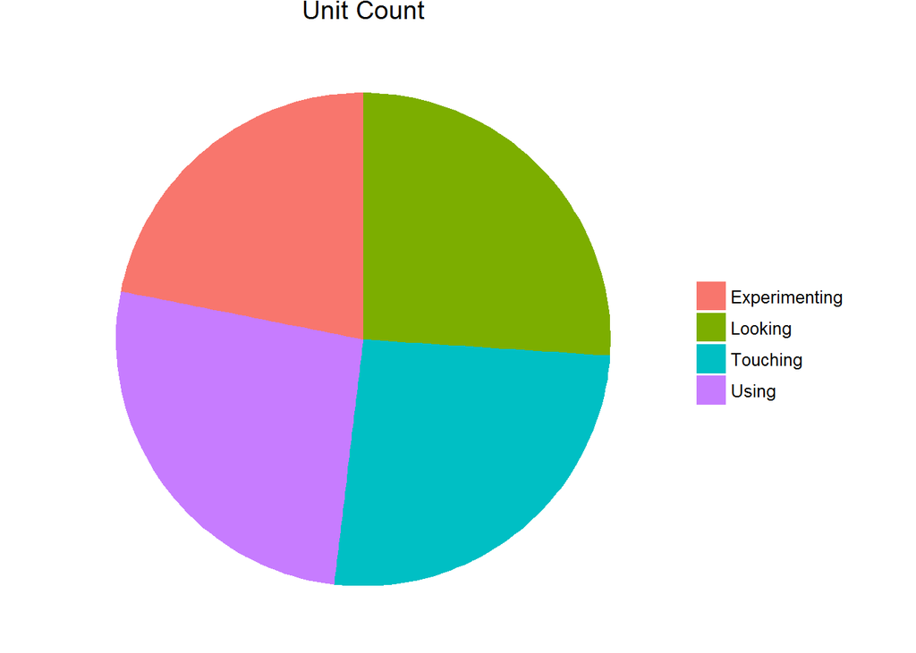

The most time is spent on experimenting with exhibits, followed by using. We can conclude that students are more engaged into direct interactions with the units rather than passive - touching or looking.

In terms of unit and student count there is no significant difference between the interaction types.

# Students Analysis

In this section the subject of analysis are students.

## Exhibit

Here we will find out which students are the most active/engaged.

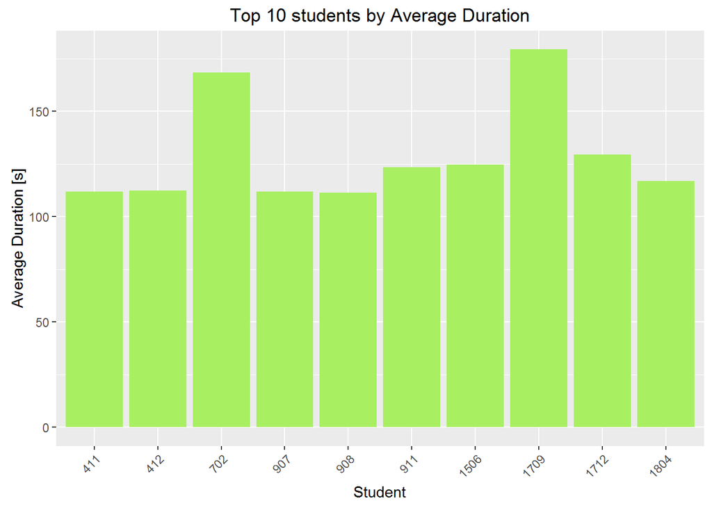

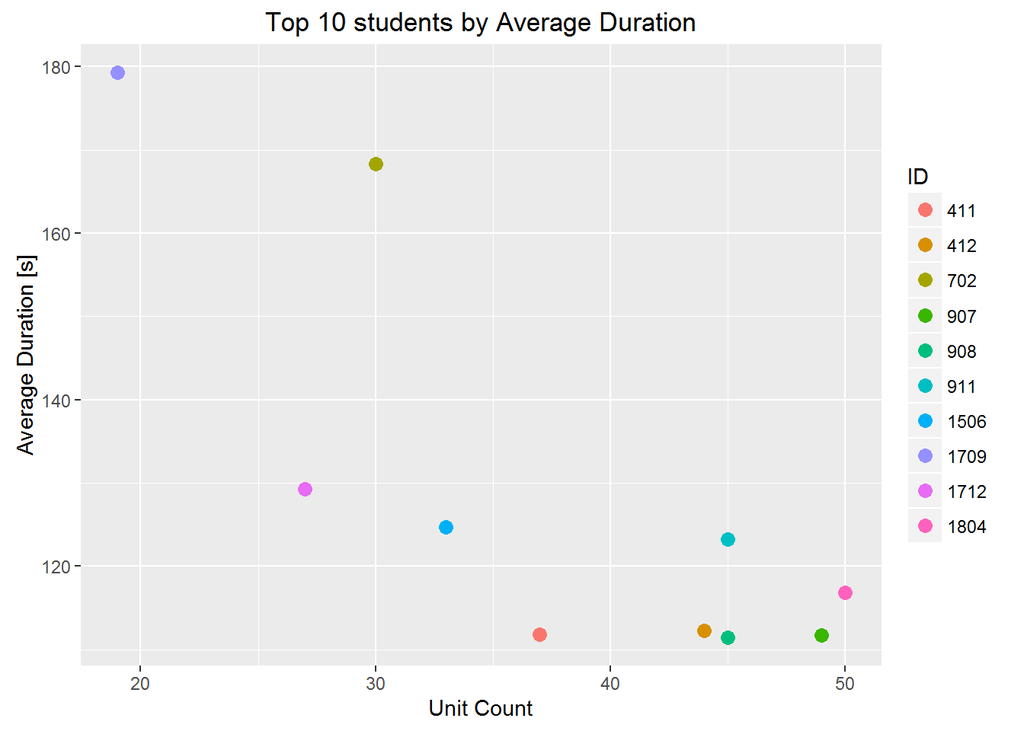

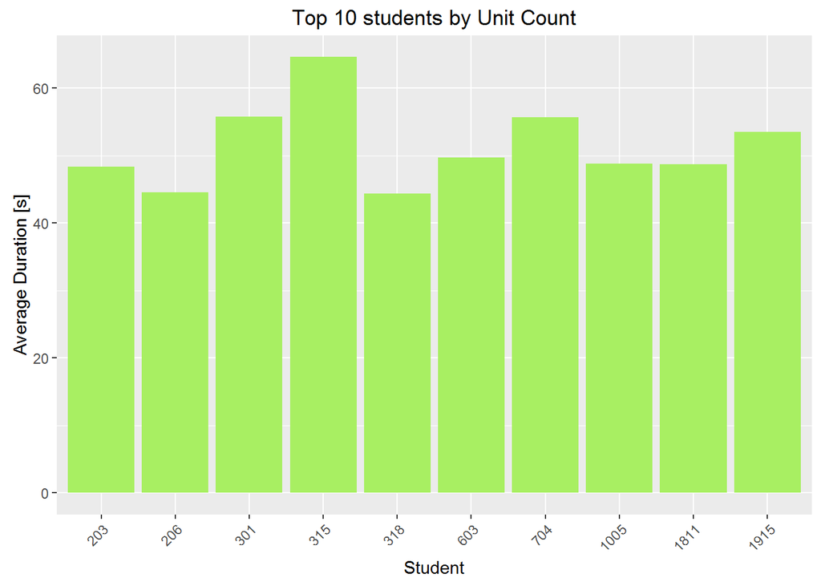

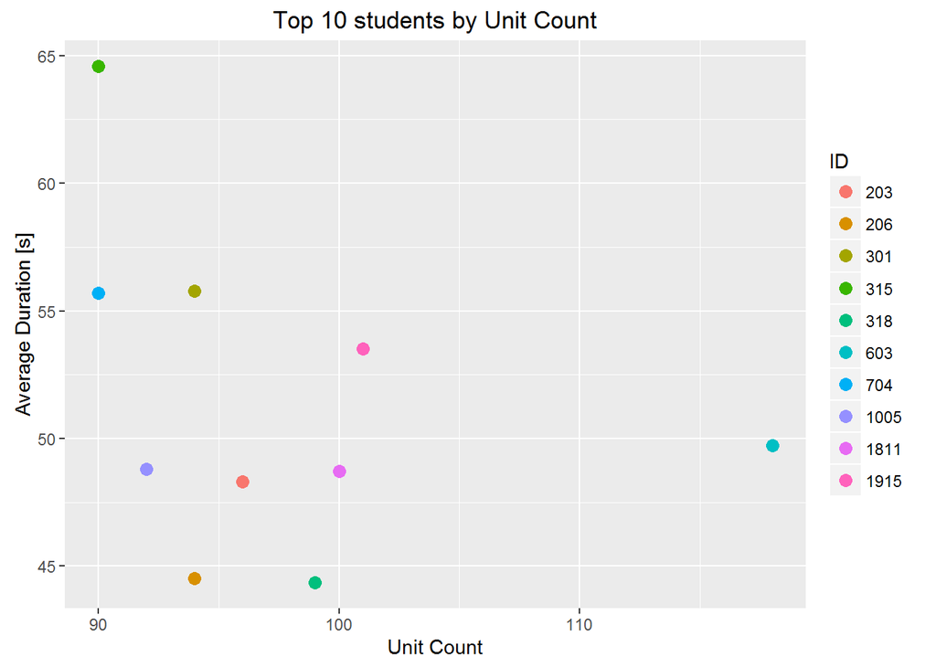

A relation between the average duration and unit count can be observed. This means that student which spent more time on units also interacted with less.